# Clustering demo for Cixiao

Ben

2023-11-30

## Libraries

```r
library(tm)
set.seed(1)
```

# Simulating data for testing methodology

## Defining a dictionary

With the code below I define a corpus just by taking a sentence from a recent BBC article.

```r
bbctext<-"In Moscow men holding reindeer antlers above their heads are dancing around a stage. It is a traditional marriage ceremony originating from the far north of Russia. Bride and groom, Ilona and Alexander, are sitting by a mock campfire and observing time-honoured rituals, like the ripping of cloth and a dance with animal furs."
bbctext<-removePunctuation(bbctext)
corpus<-unique(strsplit(bbctext,split=" ")[[1]])
n_corpus<-length(corpus)
```

I now simulate some data for $N$ users and $M$ clusters/groups.

```r
N<-128
M<-3
simmed_data<-data.frame(usernames=1:N,cluster=sample.int(M,size=N,replace=T),forecast=NA,comment=NA)
head(simmed_data)
```

```
##   usernames cluster forecast comment
## 1         1       1       NA      NA
## 2         2       3       NA      NA
## 3         3       1       NA      NA
## 4         4       2       NA      NA
## 5         5       1       NA      NA
## 6         6       3       NA      NA
```

I pretend that each forecaster produces a numerical estimate/forecast. These estimates are random variables whose expectation depends on the forecaster’s cluster.

```r
forecast_means<-seq(-1,1,length=M)*2
for(m in 1:M){
ind<-which(simmed_data$cluster==m)
simmed_data$forecast[ind]<-rnorm(length(ind),forecast_means[m],1)
}
```

I now simulate $M$ distributions over words from a Dirichlet distribution. I simulate a comment for each user using words drawn from the distribution for their cluster.

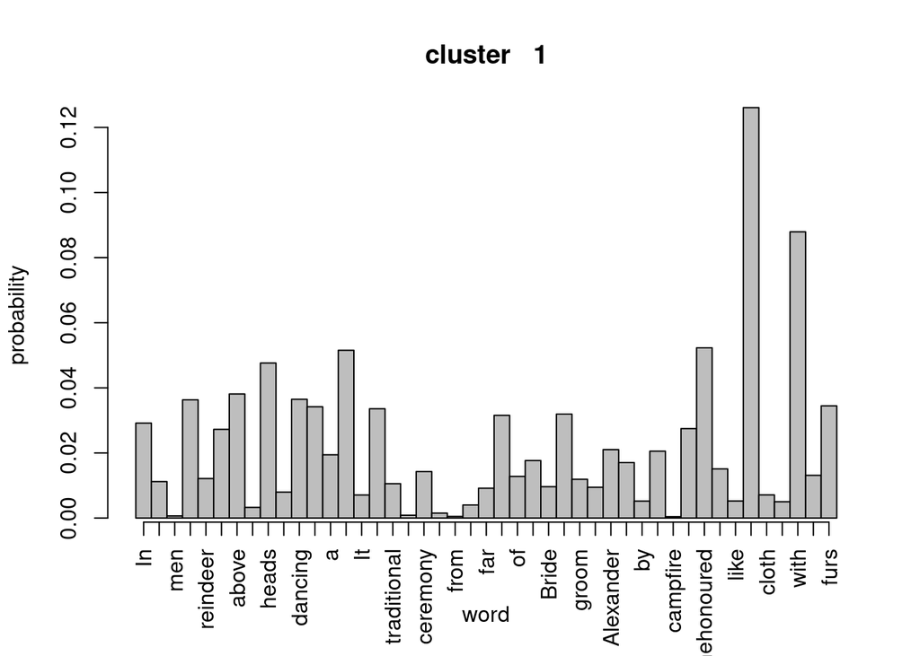

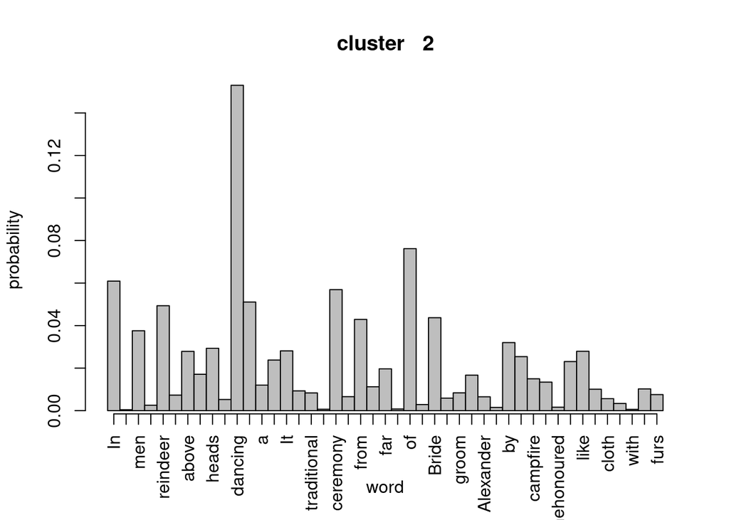

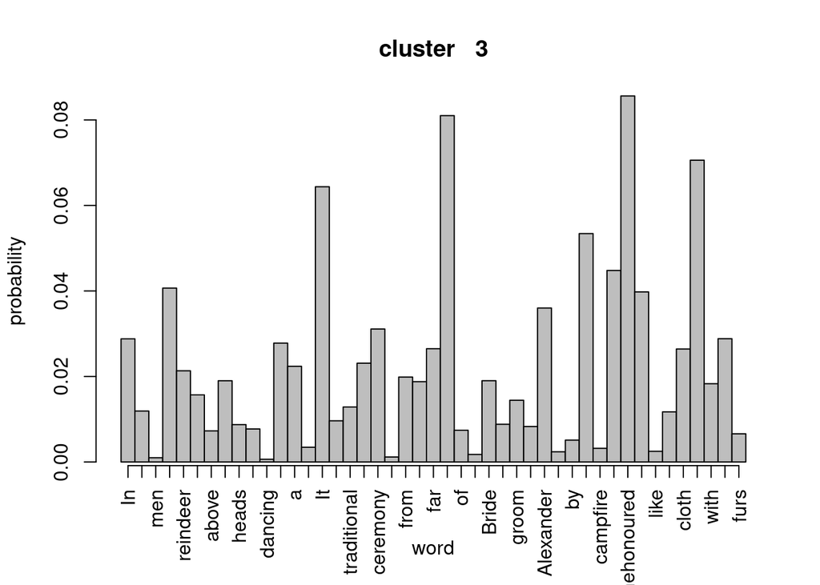

```r
text_probs<-matrix(rgamma(n_corpus*M,1,1),n_corpus,M)
text_probs<-apply(text_probs,2,function(x){x/sum(x)})
for(m in 1:M){barplot(text_probs[,m],ylab="probability",xlab="word",main=paste("cluster  ",m),space=0);axis(1,at=1:n_corpus-.5,labels=corpus,las=2)}
```

```r
comment_length<-40
for(i in 1:N){
simmed_data$comment[i]<-paste(sample(corpus,size=comment_length,replace=T,prob=text_probs[ , simmed_data$cluster[i] ]),collapse=" ")
}

head(simmed_data)
```

```
##   usernames cluster  forecast
## 1         1       1 -1.227858
## 2         2       3  1.705804
## 3         3       1 -2.219516
## 4         4       2  1.580092
## 5         5       1 -2.424810
## 6         6       3  1.385050
##                                                                                                                                                                                                                                                                                                          …
## 1   of are furs Bride with timehonoured furs holding dancing ripping In antlers heads far Alexander ripping by timehonoured ripping timehonoured antlers timehonoured timehonoured ripping timehonoured observing ripping ripping above furs north antlers ripping dancing like sitting timehonoured furs…
## 2 rituals reindeer like mock Ilona of Moscow Alexander Bride their cloth In mock timehonoured timehonoured north timehonoured mock north In timehonoured timehonoured north with from It dance dance timehonoured timehonoured north timehonoured timehonoured ceremony Bride marriage timehonoured timeh…
## 3                                         antlers antlers reindeer heads It dance ripping groom rituals antlers stage furs dancing and Bride timehonoured stage Alexander mock Bride holding animal stage with traditional ripping dancing holding dancing In mock Moscow sitting ripping with In of and …
## 4                                                            of Bride dancing around reindeer dancing heads ceremony In around the Russia mock holding men reindeer Alexander dancing dancing dancing heads above far dancing of dance reindeer of Bride men ceremony Moscow from dancing reindeer heads …
## 5                                                                 stage with timehonoured around observing above are ripping ripping furs is ceremony In far around ripping their above groom of stage with timehonoured ripping sitting with ceremony with mock around stage heads antlers and holding h…
## 6           Alexander traditional north dance north around Alexander dance holding In mock Alexander heads timehonoured ceremony rituals ripping traditional north reindeer holding animal timehonoured north and traditional north ceremony and mock north Ilona rituals dance timehonoured around holdi…
```

# Recovering the cluster numbers

I now make a copy of the simulated data but I remove the cluster numbers, which we will try to recover using the forecasts and the comments.

```r
simmed_data2<-simmed_data
simmed_data2$cluster<-NA
head(simmed_data2)
```

```
##   usernames cluster  forecast
## 1         1      NA -1.227858
## 2         2      NA  1.705804
## 3         3      NA -2.219516
## 4         4      NA  1.580092
## 5         5      NA -2.424810
## 6         6      NA  1.385050
##                                                                                                                                                                                                                                                                                                          …
## 1   of are furs Bride with timehonoured furs holding dancing ripping In antlers heads far Alexander ripping by timehonoured ripping timehonoured antlers timehonoured timehonoured ripping timehonoured observing ripping ripping above furs north antlers ripping dancing like sitting timehonoured furs…
## 2 rituals reindeer like mock Ilona of Moscow Alexander Bride their cloth In mock timehonoured timehonoured north timehonoured mock north In timehonoured timehonoured north with from It dance dance timehonoured timehonoured north timehonoured timehonoured ceremony Bride marriage timehonoured timeh…
## 3                                         antlers antlers reindeer heads It dance ripping groom rituals antlers stage furs dancing and Bride timehonoured stage Alexander mock Bride holding animal stage with traditional ripping dancing holding dancing In mock Moscow sitting ripping with In of and …
## 4                                                            of Bride dancing around reindeer dancing heads ceremony In around the Russia mock holding men reindeer Alexander dancing dancing dancing heads above far dancing of dance reindeer of Bride men ceremony Moscow from dancing reindeer heads …
## 5                                                                 stage with timehonoured around observing above are ripping ripping furs is ceremony In far around ripping their above groom of stage with timehonoured ripping sitting with ceremony with mock around stage heads antlers and holding h…
## 6           Alexander traditional north dance north around Alexander dance holding In mock Alexander heads timehonoured ceremony rituals ripping traditional north reindeer holding animal timehonoured north and traditional north ceremony and mock north Ilona rituals dance timehonoured around holdi…
```

We will estimate the cluster numbers using a Gibbs sampler (please read up on this method if you do not remember what it involves). We initialize the algorithm by simulating cluster numbers for the forecasters

```r
simmed_data2$cluster<-sample.int(M,size=N,replace=T)
```

Then, conditioning on the simulated cluster numbers, we estimate the word distributions

```r
alphamat<-matrix(1,n_corpus,M);rownames(alphamat)<-corpus;colnames(alphamat)<-paste("cluster ",1:M)
for(m in 1:M){
ind<-which(simmed_data2$cluster==m)
word_counts<-table(factor( strsplit(paste(simmed_data2$comment[ind],collapse=" "),split=" ")[[1]] ,levels=corpus))
alphamat[,m]<-1+word_counts
}
head(alphamat)
```

```
##          cluster  1 cluster  2 cluster  3
## In               82         54         60
## Moscow           17         12         18
## men              35         25         31
## holding          46         31         40
## reindeer         71         41         49
## antlers          40         19         22
```

The values in the alphamat matrix contain the alphas that parameterize the Dirichlet posterior for the word probabilities. We then sample from these posteriors and condition on these word probabilities

```r
estimated_text_probs<-matrix(NA,n_corpus,M)
rownames(estimated_text_probs)<-corpus;colnames(estimated_text_probs)<-paste("cluster ",1:M)
for(m in 1:M){
p<-rgamma(n_corpus,alphamat[,m],1)
estimated_text_probs[,m]<-p/sum(p)
}
head(estimated_text_probs)
```

```
##           cluster  1 cluster  2  cluster  3
## In       0.044046314 0.04423501 0.030409912
## Moscow   0.008085091 0.00616115 0.006908221
## men      0.012468042 0.01687544 0.017880492
## holding  0.025693469 0.02199155 0.026332224
## reindeer 0.043681282 0.02760372 0.027472931
## antlers  0.021501511 0.01608332 0.011639965
```

We also compute posterior expectations for the forecasts for each cluster

```r
estimated_forecast_means<-rep(0,M)
for(m in 1:M){
ind<-which(simmed_data$cluster==m)
estimated_forecast_means[m]<-rnorm( 1,mean=mean(simmed_data2$forecast[ind]),sd=1/(1+length(ind)) )
}
estimated_forecast_means
```

```
## [1] -1.95965602  0.03872276  2.02891158
```

Now we condition on the word distributions and forecast distributions for each cluster and simulate the cluster memberships for each user. This is another Bayesian calculation in which we compute the posterior distribution for cluster memberships, which is proportional to the prior (which for the time being I assumed is uniform) multiplied by the likelihood (please also make sure you are comfortable with this. It is very important).

```r
cluster_log_probs<-matrix(NA,N,M)
rownames(cluster_log_probs)<-paste("user ",1:N);colnames(cluster_log_probs)<-paste("cluster ",1:M)
for(i in 1:N){
word_count_i<-table(factor( strsplit(simmed_data2$comment[i],split=" ")[[1]] ,levels=corpus))
for(m in 1:M){
cluster_log_probs[i,m]<-sum(word_count_i*log(estimated_text_probs[,m]))+dnorm(simmed_data2$forecast[i],estimated_forecast_means[m],log=T)
}}

cluster_log_probs<-t(apply(cluster_log_probs,1,function(x){x-max(x)}))
cluster_probs<-t(apply(cluster_log_probs,1,function(x){exp(x)/sum(exp(x))}))

for(i in 1:N){
 simmed_data2$cluster[i]<-sample.int(M,1,prob=cluster_probs[i,])
}
head(cluster_probs)
```

```
##           cluster  1 cluster  2   cluster  3
## user  1 0.0287003989 0.97126714 3.246462e-05
## user  2 0.0003282205 0.07357177 9.261000e-01
## user  3 0.9199697525 0.08002655 3.692795e-06
## user  4 0.0002147832 0.01051158 9.892736e-01
## user  5 0.5762729730 0.42372639 6.361515e-07
## user  6 0.0521936139 0.01430221 9.335042e-01
```

Now we return to step in which we estimate the word distributions and forecast distribution conditional on the cluster memberships… and we repeat this many times. This takes about a minute.

```r
N_its<-2000
pb<-txtProgressBar(min = 0, max = N_its, initial = 0,style=3)
for(its in 1:N_its){
setTxtProgressBar(pb,its)

for(m in 1:M){
ind<-which(simmed_data2$cluster==m)
word_counts<-table(factor( strsplit(paste(simmed_data2$comment[ind],collapse=" "),split=" ")[[1]] ,levels=corpus))
alphamat[,m]<-1+word_counts
}

for(m in 1:M){
p<-rgamma(n_corpus,alphamat[,m],1)
estimated_text_probs[,m]<-p/sum(p)
}

for(m in 1:M){
ind<-which(simmed_data$cluster==m)
estimated_forecast_means[m]<-rnorm( 1,mean=mean(simmed_data2$forecast[ind]),sd=1/(1+length(ind)) )
}

for(i in 1:N){
word_count_i<-table(factor( strsplit(simmed_data2$comment[i],split=" ")[[1]] ,levels=corpus))
for(m in 1:M){
cluster_log_probs[i,m]<-sum(word_count_i*log(estimated_text_probs[,m]))+dnorm(simmed_data2$forecast[i],estimated_forecast_means[m],log=T)
}}

cluster_log_probs<-t(apply(cluster_log_probs,1,function(x){x-max(x)}))
cluster_probs<-t(apply(cluster_log_probs,1,function(x){exp(x)/sum(exp(x))}))

for(i in 1:N){
 simmed_data2$cluster[i]<-sample.int(M,1,prob=cluster_probs[i,])
}
}
save(simmed_data2,file="simmed_data2.RData")
```

Now we can compare a simulated set of cluster memberships (simulated from our posterior distribution using the Gibbs sampler) and the true cluster memberships (which we know because we simulated them).

```r
load(file="simmed_data2.RData")
simmed_data2$cluster
```

```
##   [1] 2 3 2 1 2 3 3 1 1 3 3 2 2 2 1 1 1 1 3 2 3 2 2 2 2 1 2 2 1 1 1 2 3 2 3 1 1
##  [38] 1 1 3 1 2 3 1 2 2 3 1 1 3 3 1 1 1 1 2 1 1 1 1 2 3 3 1 3 3 1 3 3 2 2 2 2 3
##  [75] 1 3 2 2 1 2 2 2 2 3 1 2 2 3 3 3 1 1 1 3 1 1 3 3 3 2 1 1 2 3 3 1 3 1 2 1 2
## [112] 3 3 2 1 2 3 1 3 3 2 2 1 1 1 2 2 2
```

```r
simmed_data$cluster
```

```
##   [1] 1 3 1 2 1 3 3 2 2 3 3 1 1 1 2 2 2 2 3 1 3 1 1 1 1 2 1 1 2 2 2 1 3 1 3 2 2
##  [38] 2 2 3 2 1 3 2 1 1 3 2 2 3 3 2 2 2 2 1 2 2 2 2 1 3 3 2 3 3 2 3 3 1 1 1 1 3
##  [75] 2 3 1 1 2 1 1 1 1 3 2 1 1 3 3 3 2 2 2 3 2 2 3 3 3 1 2 2 1 3 3 2 3 2 1 2 1
## [112] 3 3 1 2 1 3 2 3 3 1 1 2 2 2 1 1 1
```

We should see that the simulated clustering tends to put users in the same cluster if they really were from the same cluster. Obviously the label for the cluster might be different though.